# Day 2

# 1 Preliminaries

Set the **working directory** to its location. In RStudio,

````
 ```
 Session > Set Working Directory > To Source File Location
 ```
````

## 1.1 - Use the `install.packages` function to install the `lmerTest`, `brms`, `tidybayes`, and `dplyr` packages.

```r
# Install the packages
install.packages(
     pkgs = c("lmerTest", "brms", "tidybayes", "dplyr"),
     repos = "http://cloud.r-project.org"
)
```

## 1.2 - Use the `library` function to load the packages.

```r
# Load the packages
library(lmerTest)# important because otherwise you don't get p-values!
library(brms)
library(tidybayes)
library(dplyr)
```

## 1.3 - Use the `load` function to load the `PracticalDay2.RData` environment into your workspace.

```r
load("PracticalDay2.RData")
```

# 2 Part 3: Assumptions, Data Centering, Complete Multilevel Analysis

These assignments are about a study on the popularity of highschool students. A total of 246 students from 12 different classes took part in this study in which we determined how `Extraversion`, `Gender`, and teacher experience (`teacherExp`) influenced a student’s popularity.

The data for the 12 different classes are stored in de the dataframes Class1 - Class12. The dataframe `Total` contains the combined data of all classes.

List of all the variables:

- `pupil`: pupil identification variable
- `class`: class identification variable
- student-level independent variables: `Extraversion` (continuous; higher scores mean higher extraversion) and `Gender` (dichotomous; 0 = `male`, 1 = `female`)
- class-level independent variables: teacher experience `teacherExp` in years
- outcome variable: `Popular` (continuous: higher scores indicate higher popularity).

## 2.1 - Assignment 1: Assumptions

Run a Multilevel Analysis with both the level-1 and level-2 predictors, and a random effects for the level-1 predictors. As always we should start with exploring and visualizing our data, but since we already visualized this data on Day 1, and to keep the assignment short, we will only look at the assumptions of normality of errors and linearity here. The reason is that these are the two assumptions that require some more work in a multilevel analyses since we have multiple residual (on level 1 and level 2) and have relationships at both level 1 and level 2. So:

- Check the normality of the errors for this model. Tip: Look up the residual and ranef commands
- Check the assumptions of linearity for all predictors. Tip: Remember what the level-2 DV is, and see the assignment from day 1 on how to calculate it.

### 2.1.1 - Frequentist multilevel regression analysis

```r
# Running the multilevel regression analysis
Regr6_ML <- lmer(Popular ~ 1 + Gender + Extraversion + teacherExp +
                   (1 + Gender + Extraversion | Class), data = Total)
```

Note that you get a warning message with this analysis. As mentioned, multilevel models can get quite complex quickly which can be an issue for frequentist analyses. In addition, frequentist analysis is not great at indicating if a problem is a big problem or not. We therefore do not know if we can trust our results now. Bayesian analysis performs better in this regard. It can handle complex models more easily and clearly tells us if there is an important issue (and allows for diagnosing the problem and adjusting the calculations accordingly). We will therefore also run a Bayesian analysis on these data.

### 2.1.2 - Bayesian multilevel regression analysis

```r
Regr6_Bayes <- brm(Popular ~ 1 + Gender + Extraversion + teacherExp +
                   (1 + Gender + Extraversion | Class), data = Total)
```

The Bayesian analysis finishes without issues. Comparing the frequentist and Bayesian results allows us to see if the frequentist results are also reliable.

```r
summary(Regr6_ML)
```

```
Linear mixed model fit by REML. t-tests use Satterthwaite's method ['lmerModLmerTest']
Formula: Popular ~ 1 + Gender + Extraversion + teacherExp + (1 + Gender +
    Extraversion | Class)
   Data: Total

REML criterion at convergence: 557

Scaled residuals:
     Min       1Q   Median       3Q      Max
-2.82102 -0.60102  0.07982  0.70373  2.48140

Random effects:
 Groups   Name         Variance Std.Dev. Corr
 Class    (Intercept)  0.265309 0.51508
          Gender       0.007786 0.08824  -1.00
          Extraversion 0.022318 0.14939  -0.14  0.14
 Residual              0.464217 0.68134
Number of obs: 246, groups:  Class, 12

Fixed effects:
             Estimate Std. Error       df t value Pr(>|t|)
(Intercept)   3.48340    0.39277 11.03931   8.869 2.36e-06 ***
Gender        1.02828    0.09238 55.88435  11.131 8.40e-16 ***
Extraversion  0.47374    0.06025 10.52148   7.863 1.01e-05 ***
teacherExp    0.04575    0.02531 10.18699   1.808      0.1
---
Signif. codes:  0 '***' 0.001 '**' 0.01 '*' 0.05 '.' 0.1 ' ' 1

Correlation of Fixed Effects:
            (Intr) Gender Extrvr
Gender      -0.207
Extraversin -0.063  0.002
teacherExp  -0.912 -0.004  0.031
optimizer (nloptwrap) convergence code: 0 (OK)
boundary (singular) fit: see help('isSingular')
```

```r
summary(Regr6_Bayes)
```

```
 Family: gaussian
  Links: mu = identity; sigma = identity
Formula: Popular ~ 1 + Gender + Extraversion + teacherExp + (1 + Gender + Extraversion | Class)
   Data: Total (Number of observations: 246)
  Draws: 4 chains, each with iter = 2000; warmup = 1000; thin = 1;
         total post-warmup draws = 4000

Group-Level Effects:
~Class (Number of levels: 12)
                            Estimate Est.Error l-95% CI u-95% CI Rhat Bulk_ESS Tail_ESS
sd(Intercept)                   0.59      0.17     0.34     0.99 1.00     1568     2093
sd(Gender)                      0.12      0.09     0.00     0.35 1.00     2202     1951
sd(Extraversion)                0.17      0.08     0.02     0.36 1.00     1106      691
cor(Intercept,Gender)          -0.19      0.48    -0.93     0.79 1.00     5229     2428
cor(Intercept,Extraversion)    -0.07      0.41    -0.79     0.73 1.00     1715     2346
cor(Gender,Extraversion)       -0.02      0.49    -0.89     0.87 1.00     1461     2221

Population-Level Effects:
             Estimate Est.Error l-95% CI u-95% CI Rhat Bulk_ESS Tail_ESS
Intercept        3.46      0.56     2.36     4.56 1.00     1129     1937
Gender           1.03      0.10     0.83     1.23 1.00     5141     2642
Extraversion     0.47      0.07     0.34     0.61 1.00     3145     2353
teacherExp       0.05      0.04    -0.03     0.12 1.00     1152     1768

Family Specific Parameters:
      Estimate Est.Error l-95% CI u-95% CI Rhat Bulk_ESS Tail_ESS
sigma     0.69      0.03     0.63     0.76 1.00     5708     3260

Draws were sampled using sampling(NUTS). For each parameter, Bulk_ESS
and Tail_ESS are effective sample size measures, and Rhat is the potential
scale reduction factor on split chains (at convergence, Rhat = 1).
```

Results are quite close although the standard errors (SEs) differ a bit. In the frequentist analysis, for example, the intercept has an SE of 0.39, while in the Bayesian analysis, this SE is equal to .56. Other SEs are quite similar. We can do two things now: 1) conclude the frequentists analysis is reliable enough and continue with it, or 2) continue with the Bayesian analysis. To decide, let’s see if we can figure out why we get the warning with the frequentists analysis. As mentioned, Bayesian analysis let’s you explore your model and its compuation in more detail, so let’s look at the distributions of the model parameters from the Bayesian analysis.

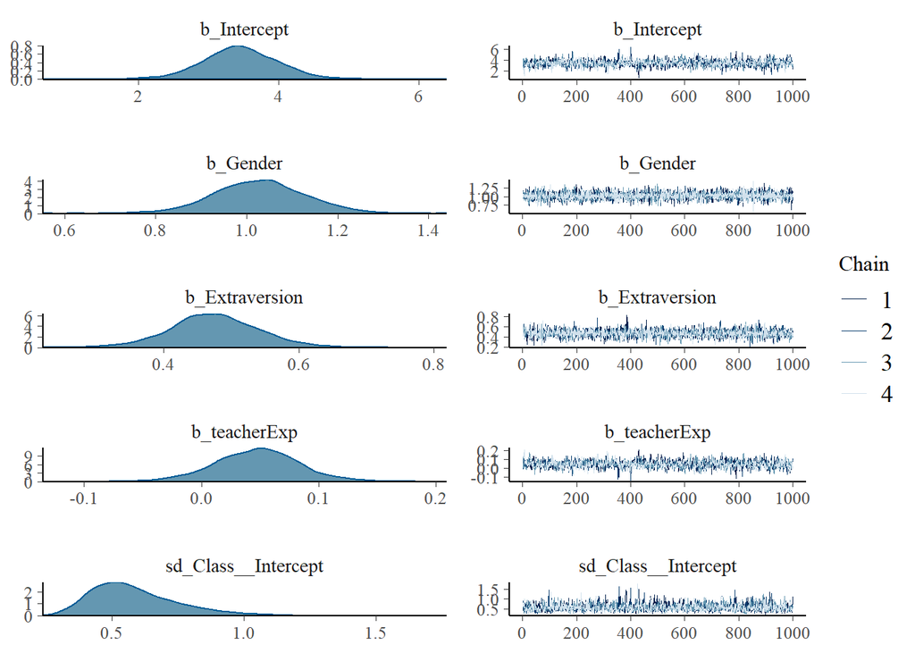

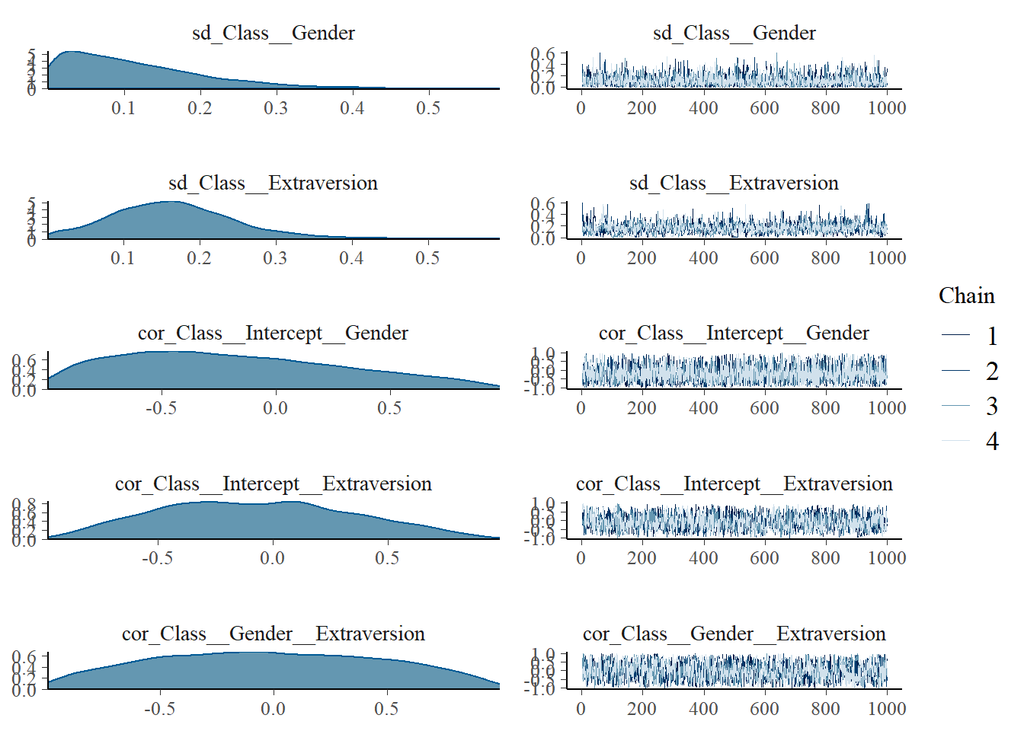

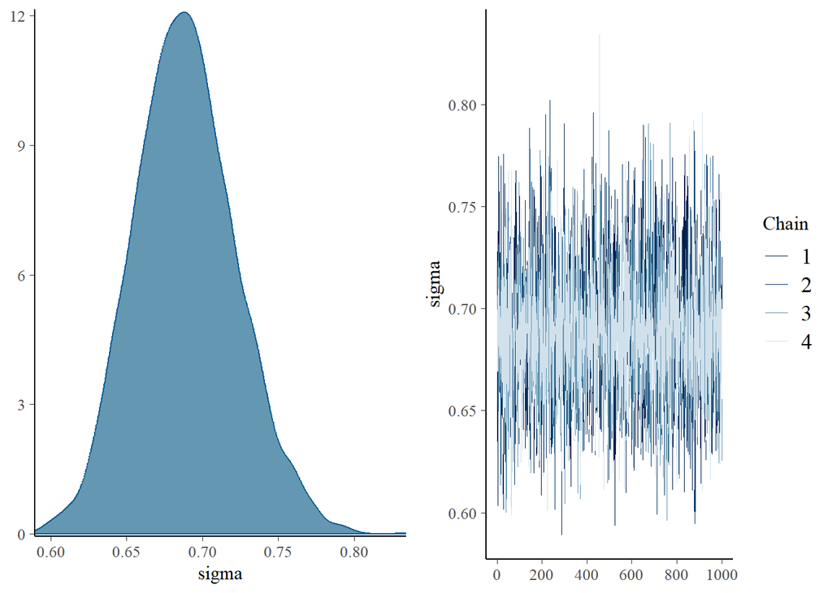

```r
plot(Regr6_Bayes)
```

Note that between class differences in `Gender` (the between class SD of `Gender`, `sd_Class_Gender`) is very skewed and has a lot of values really close to 0. This is likely the cause of the warning with the frequentist analysis. SDs do not get smaller than 0, in statistical terms, 0 is a boundary value for a SD. Frequentists analyses do not like parameter values close to boundaries (0 for SDs/variances, +/- 1 for correlations) and give warnings when this happens. From our visualizations, we know that the proportion of males and females is quite equal in all classes, so a small between-class SD for this variable makes sense here. Because of that, we decide that continuing with the frequentist analysis is also a good option, and we move on to checking normality and linearity for this analysis type.

### 2.1.3 - Checking the normality of the errors

#### 2.1.3.1 - For level 1

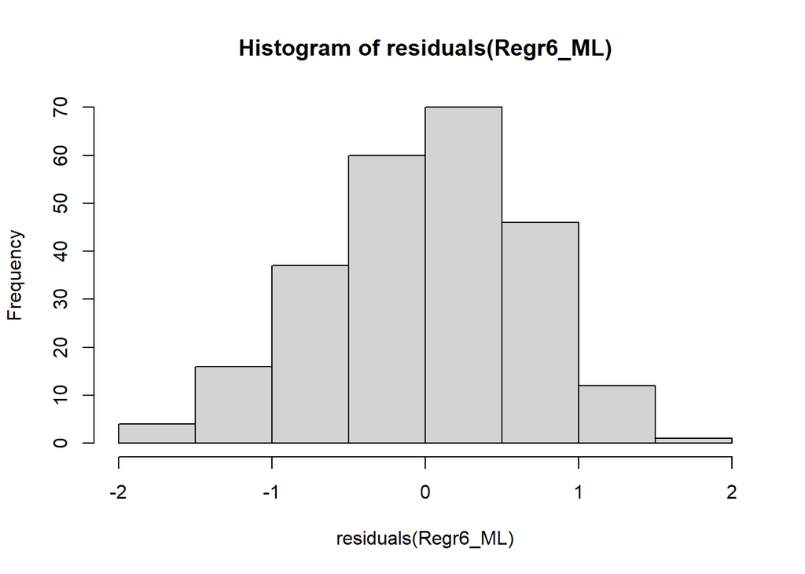

```r
hist(residuals(Regr6_ML))
```

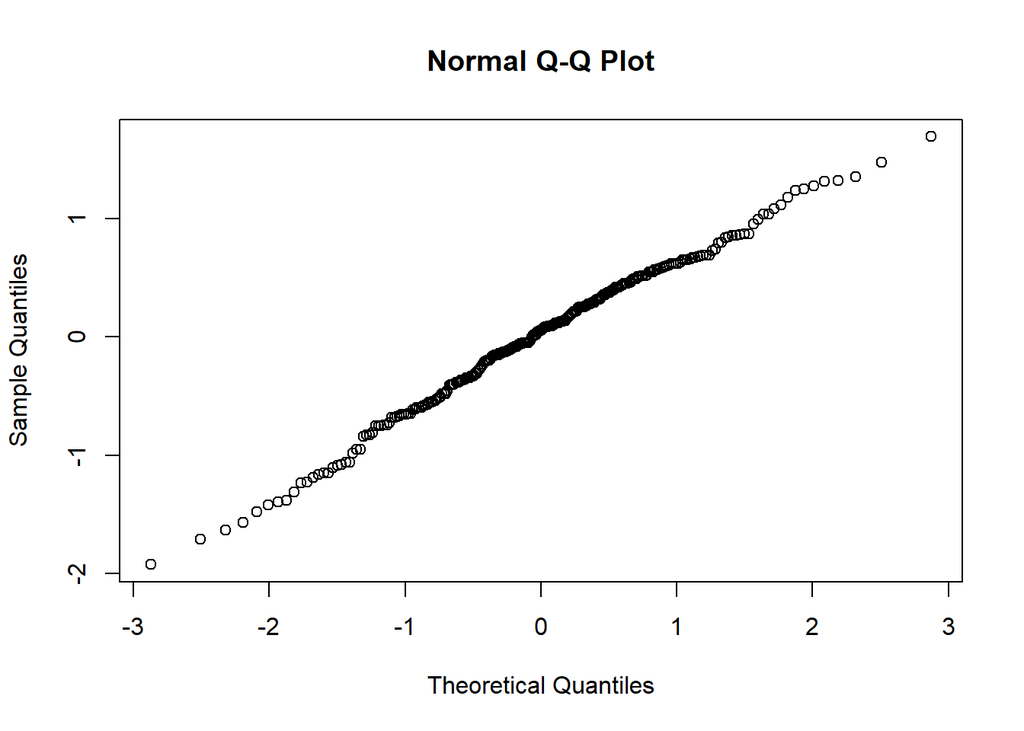

```r
qqnorm(residuals(Regr6_ML))
```

This looks fine.

#### 2.1.3.2 - For level 2

```r
ranef(Regr6_ML) # gives the random effects
```

```
$Class
   (Intercept)       Gender  Extraversion
1   0.07975249 -0.013662399 -0.0298395410
2  -0.40448564  0.069292436 -0.0002527382
3  -0.17510982  0.029998063  0.1095741156
4   0.74285641 -0.127258733 -0.0909101037
5   0.58463273 -0.100153434  0.1577380991
6   0.01867717 -0.003199586  0.0548410280
7  -0.48472558  0.083038341 -0.1343872713
8  -0.92174541  0.157904208  0.1405876292
9   0.31308643 -0.053634838  0.0464549902
10  0.36254548 -0.062107667 -0.1751501939
11 -0.04242682  0.007268139 -0.0818635687
12 -0.07305744  0.012515470  0.0032075547

with conditional variances for "Class"
```

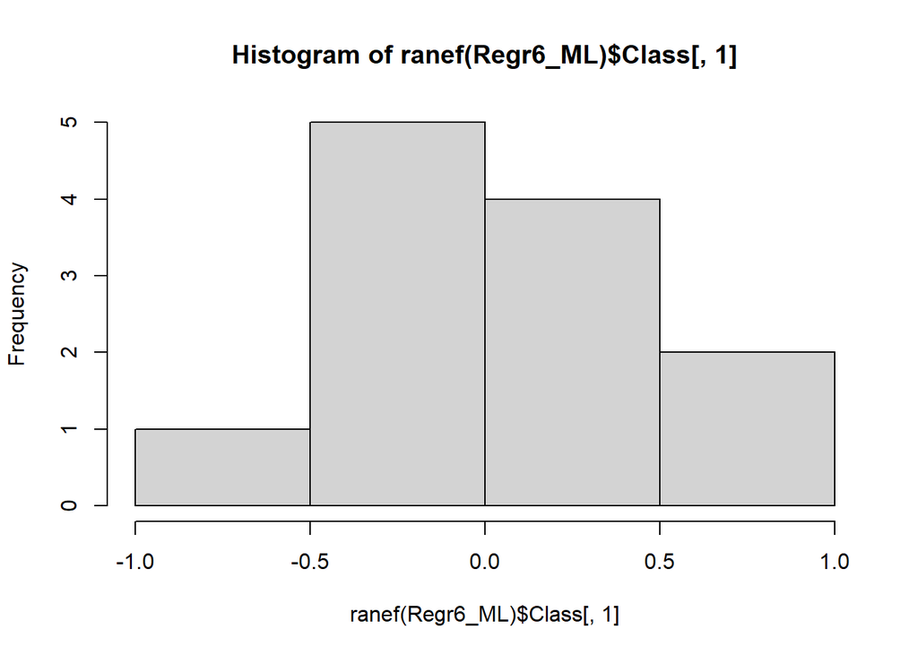

```r
hist(ranef(Regr6_ML)$Class[,1]) # intercept
```

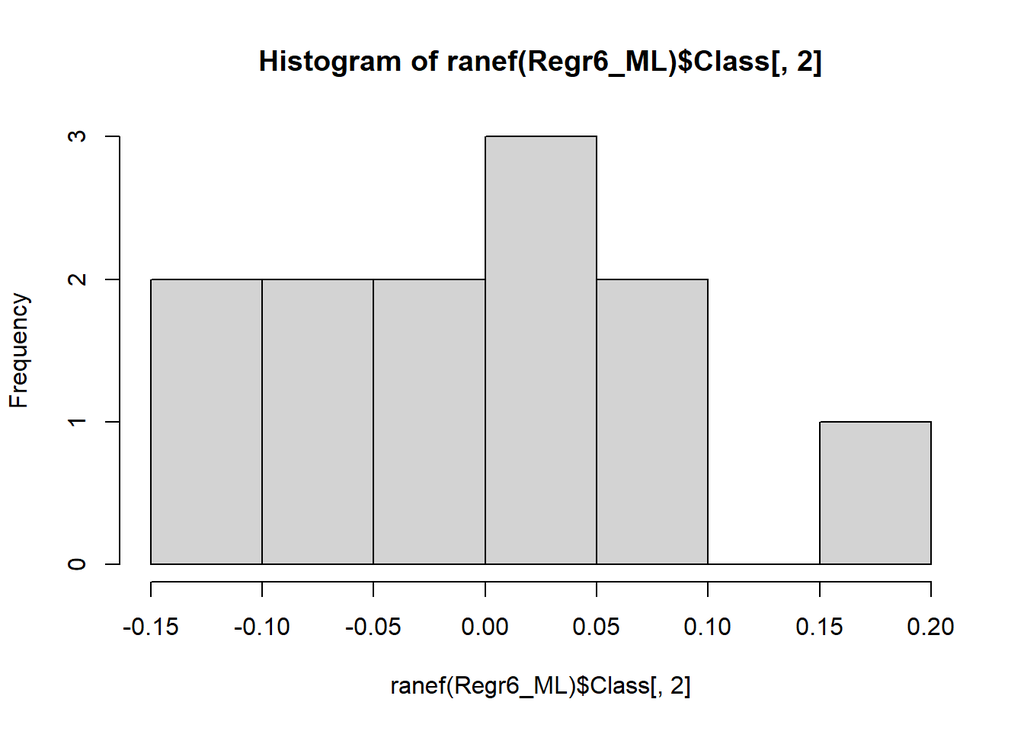

```r
hist(ranef(Regr6_ML)$Class[,2]) # Gender
```

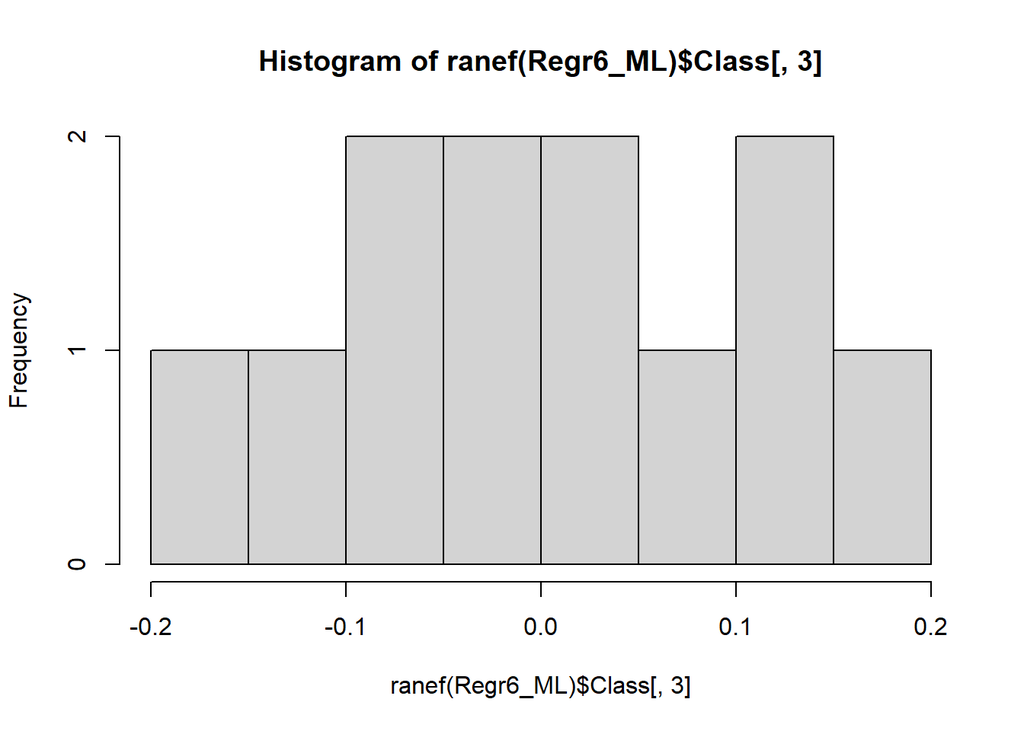

```r
hist(ranef(Regr6_ML)$Class[,3]) # Extraversion
```

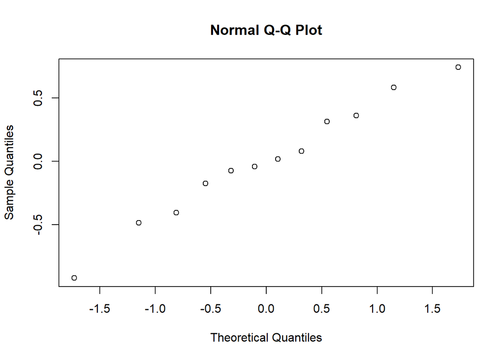

```r
qqnorm(ranef(Regr6_ML)$Class[,1]) # intercept
```

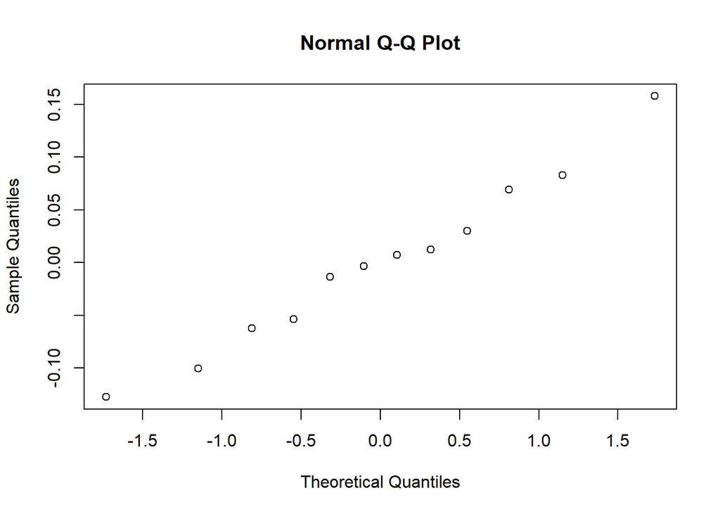

```r
qqnorm(ranef(Regr6_ML)$Class[,2]) # Gender
```

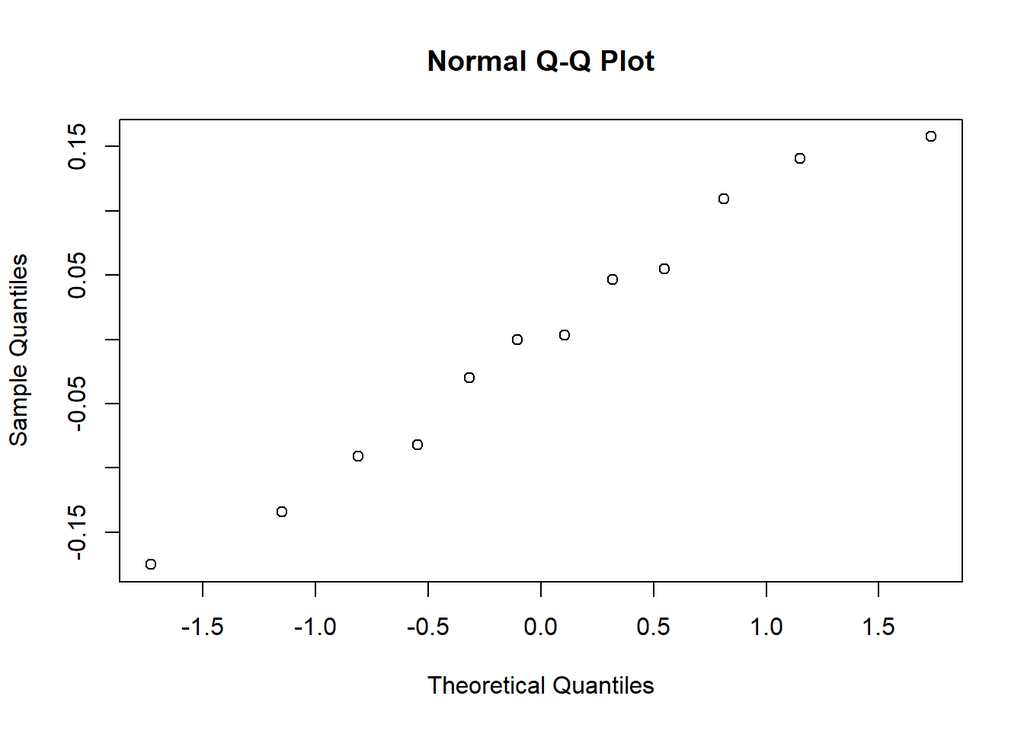

```r
qqnorm(ranef(Regr6_ML)$Class[,3]) # Extraversion
```

These look okay. The histograms look non-normal but the qq-plots are decent. Remember that we have a very small sample size on level 2 of only 12 classes. Because of this, the figures will always look less nice. Since the qq-plots look okay and since the analyses are quite robust against some violation of the normality assumption, we conclude that this is all fine.

### 2.1.4 - Checking the assumptions of linearity

We already did this on day 1 with ggpairs, but can also use separate scatter plots to test this assumption, especially if the number of predictors, and therefore the number of plots, is not too large. In case of many predictors looking at the residual for violations of linearity for your model as a whole is easier.

#### 2.1.4.1 - For level 1

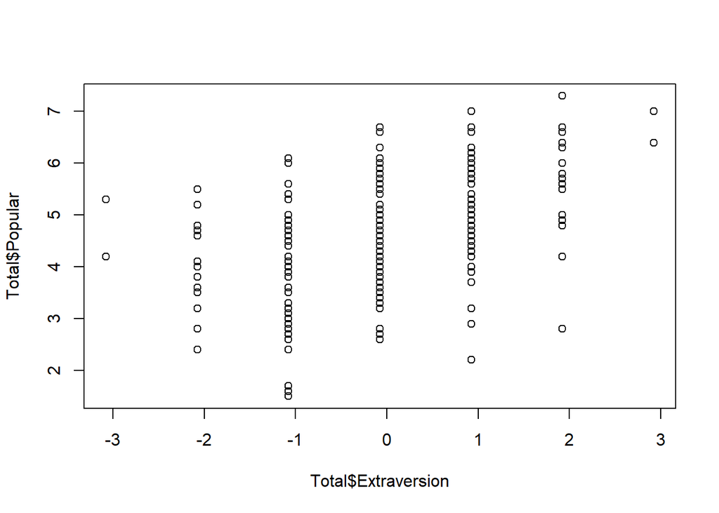

```r
plot(Total$Extraversion, Total$Popular)
```

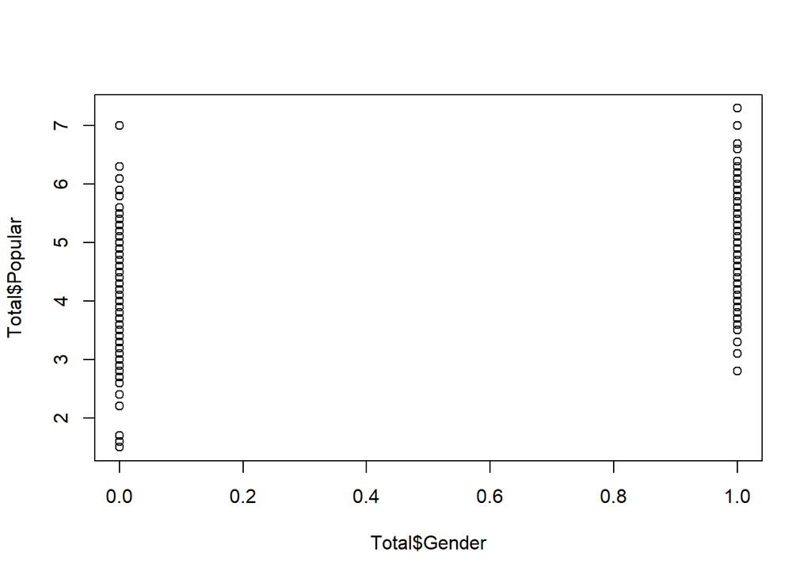

```r
plot(Total$Gender, Total$Popular)
```

#### 2.1.4.2 - For level 2

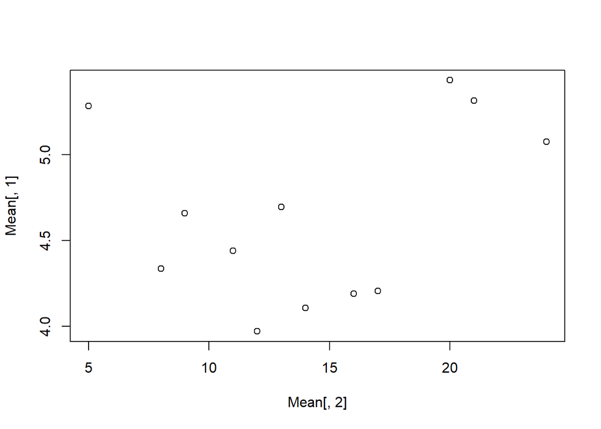

```r
# First we create a matrix in which we store the intercepts and coefficients
Mean <- matrix(NA, ncol = 2, nrow = 12)
colnames(Mean) <- c("Popular", "TeacherExperience")

# Then, we automatically run lm on all the 12 classes and store
# the results.
for (i in 1:12) {
  Mean[i, 1] <- mean(eval(parse(text = paste("Class", i, sep = "")))$Popular)
  Mean[i, 2] <- mean(eval(parse(text = paste("Class", i, sep = "")))$teacherExp)
}

plot(Mean[,2],Mean[,1])
```

Because of the small level-2 sample size, the plot again does not look great, but there is also no clear non-linear trend visible, so we conclude that all is fine.

## 2.2 - Assignment 2: Grand Centering

Grand center the continuous predictors and rerun the model. What do you notice when comparing the results to the model with the uncentered predictors?

### 2.2.1 - Level-1 predictor

```r
Total$Extraversion_c <- Total$Extraversion - mean(Total$Extraversion)
```

### 2.2.2 - Level-2 predictor

```r
# We're going to do this in two steps, because we can't use the raw `teacherExp`
# scores. The reason for that is that each student has a `teacherExp`score in
# the datafile, while `teacherExp`obviously is a class characteristic. So we'll
# first determine the average `teacherExp` for each class (which is just the
# `teacherExp` score for that class), and then calculate the average of those
# class-scores for centering.
Teacher_Exp <- matrix(NA, ncol = 1, nrow = 12)

for (i in 1:12) {
  Teacher_Exp[i,] <- mean(Total$teacherExp[Total$Class==i])
}

Teacher_Exp
```

```
      [,1]
 [1,]   24
 [2,]   14
 [3,]   13
 [4,]   20
 [5,]    5
 [6,]    8
 [7,]   17
 [8,]   12
 [9,]    9
[10,]   21
[11,]   11
[12,]   16
```

```r
mean(Teacher_Exp)
```

```
[1] 14.16667
```

```r
Total$TE_c <- Total$teacherExp - mean(Teacher_Exp)
```

### 2.2.3 - Rerun the model and compare to previous results

```r
Regr6_ML2 <- lmer(Popular ~ 1 + Gender + Extraversion_c + TE_c +
                    (1 + Gender + Extraversion_c | Class), data = Total)
summary(Regr6_ML2)
```

```
Linear mixed model fit by REML. t-tests use Satterthwaite's method ['lmerModLmerTest']
Formula: Popular ~ 1 + Gender + Extraversion_c + TE_c + (1 + Gender +      Extraversion_c | Class)
   Data: Total

REML criterion at convergence: 557

Scaled residuals:
     Min       1Q   Median       3Q      Max
-2.82102 -0.60102  0.07982  0.70373  2.48140

Random effects:
 Groups   Name           Variance Std.Dev. Corr
 Class    (Intercept)    0.265309 0.51508
          Gender         0.007786 0.08824  -1.00
          Extraversion_c 0.022318 0.14939  -0.14  0.14
 Residual                0.464217 0.68134
Number of obs: 246, groups:  Class, 12

Fixed effects:
               Estimate Std. Error       df t value Pr(>|t|)
(Intercept)     4.13151    0.16130 10.43410  25.614 9.26e-11 ***
Gender          1.02828    0.09238 55.88435  11.131 8.40e-16 ***
Extraversion_c  0.47374    0.06025 10.52148   7.863 1.01e-05 ***
TE_c            0.04575    0.02531 10.18699   1.808      0.1
---
Signif. codes:  0 '***' 0.001 '**' 0.01 '*' 0.05 '.' 0.1 ' ' 1

Correlation of Fixed Effects:
            (Intr) Gender Extrv_
Gender      -0.513
Extravrsn_c -0.086  0.002
TE_c         0.002 -0.004  0.031
optimizer (nloptwrap) convergence code: 0 (OK)
boundary (singular) fit: see help('isSingular')
```

```r
# Compare to the results of the model with the uncentered predictors
summary(Regr6_ML)
```

```
Linear mixed model fit by REML. t-tests use Satterthwaite's method ['lmerModLmerTest']
Formula: Popular ~ 1 + Gender + Extraversion + teacherExp + (1 + Gender +
    Extraversion | Class)
   Data: Total

REML criterion at convergence: 557

Scaled residuals:
     Min       1Q   Median       3Q      Max
-2.82102 -0.60102  0.07982  0.70373  2.48140

Random effects:
 Groups   Name         Variance Std.Dev. Corr
 Class    (Intercept)  0.265309 0.51508
          Gender       0.007786 0.08824  -1.00
          Extraversion 0.022318 0.14939  -0.14  0.14
 Residual              0.464217 0.68134
Number of obs: 246, groups:  Class, 12

Fixed effects:
             Estimate Std. Error       df t value Pr(>|t|)
(Intercept)   3.48340    0.39277 11.03931   8.869 2.36e-06 ***
Gender        1.02828    0.09238 55.88435  11.131 8.40e-16 ***
Extraversion  0.47374    0.06025 10.52148   7.863 1.01e-05 ***
teacherExp    0.04575    0.02531 10.18699   1.808      0.1
---
Signif. codes:  0 '***' 0.001 '**' 0.01 '*' 0.05 '.' 0.1 ' ' 1

Correlation of Fixed Effects:
            (Intr) Gender Extrvr
Gender      -0.207
Extraversin -0.063  0.002
teacherExp  -0.912 -0.004  0.031
optimizer (nloptwrap) convergence code: 0 (OK)
boundary (singular) fit: see help('isSingular')
```

```r
# Or to make things easier compare the fixed and random effects separately
coef(summary(Regr6_ML)) #this gives you the fixed effects estimates
```

```
               Estimate Std. Error       df   t value     Pr(>|t|)
(Intercept)  3.48339610 0.39276602 11.03931  8.868884 2.358462e-06
Gender       1.02827846 0.09237888 55.88435 11.131100 8.398327e-16
Extraversion 0.47374481 0.06025260 10.52148  7.862645 1.009419e-05
teacherExp   0.04574901 0.02530727 10.18699  1.807742 1.002213e-01
```

```r
coef(summary(Regr6_ML2))
```

```
                 Estimate Std. Error       df   t value     Pr(>|t|)
(Intercept)    4.13150714 0.16130081 10.43410 25.613679 9.260620e-11
Gender         1.02827846 0.09237888 55.88435 11.131100 8.398327e-16
Extraversion_c 0.47374481 0.06025260 10.52148  7.862645 1.009419e-05
TE_c           0.04574901 0.02530727 10.18699  1.807742 1.002213e-01
```

```r
VarCorr(Regr6_ML) #this gives you the random effects Std.Dev
```

```
 Groups   Name         Std.Dev. Corr
 Class    (Intercept)  0.515081
          Gender       0.088239 -1.000
          Extraversion 0.149393 -0.138  0.138
 Residual              0.681335
```

```r
VarCorr(Regr6_ML2)
```

```
 Groups   Name           Std.Dev. Corr
 Class    (Intercept)    0.515081
          Gender         0.088239 -1.000
          Extraversion_c 0.149393 -0.138  0.138
 Residual                0.681335
```

### 2.2.4 - Rerun the model

```r
Regr6_ML2 <- lmer(Popular ~ 1 + Gender + Extraversion_c + TE_c +
                    (1 + Gender + Extraversion_c | Class), data = Total)
summary(Regr6_ML2)
```

```
Linear mixed model fit by REML. t-tests use Satterthwaite's method ['lmerModLmerTest']
Formula: Popular ~ 1 + Gender + Extraversion_c + TE_c + (1 + Gender +      Extraversion_c | Class)
   Data: Total

REML criterion at convergence: 557

Scaled residuals:
     Min       1Q   Median       3Q      Max
-2.82102 -0.60102  0.07982  0.70373  2.48140

Random effects:
 Groups   Name           Variance Std.Dev. Corr
 Class    (Intercept)    0.265309 0.51508
          Gender         0.007786 0.08824  -1.00
          Extraversion_c 0.022318 0.14939  -0.14  0.14
 Residual                0.464217 0.68134
Number of obs: 246, groups:  Class, 12

Fixed effects:
               Estimate Std. Error       df t value Pr(>|t|)
(Intercept)     4.13151    0.16130 10.43410  25.614 9.26e-11 ***
Gender          1.02828    0.09238 55.88435  11.131 8.40e-16 ***
Extraversion_c  0.47374    0.06025 10.52148   7.863 1.01e-05 ***
TE_c            0.04575    0.02531 10.18699   1.808      0.1
---
Signif. codes:  0 '***' 0.001 '**' 0.01 '*' 0.05 '.' 0.1 ' ' 1

Correlation of Fixed Effects:
            (Intr) Gender Extrv_
Gender      -0.513
Extravrsn_c -0.086  0.002
TE_c         0.002 -0.004  0.031
optimizer (nloptwrap) convergence code: 0 (OK)
boundary (singular) fit: see help('isSingular')
```

### 2.2.5 - Compare to previous results

```r
summary(Regr6_ML)
```

```
Linear mixed model fit by REML. t-tests use Satterthwaite's method ['lmerModLmerTest']
Formula: Popular ~ 1 + Gender + Extraversion + teacherExp + (1 + Gender +
    Extraversion | Class)
   Data: Total

REML criterion at convergence: 557

Scaled residuals:
     Min       1Q   Median       3Q      Max
-2.82102 -0.60102  0.07982  0.70373  2.48140

Random effects:
 Groups   Name         Variance Std.Dev. Corr
 Class    (Intercept)  0.265309 0.51508
          Gender       0.007786 0.08824  -1.00
          Extraversion 0.022318 0.14939  -0.14  0.14
 Residual              0.464217 0.68134
Number of obs: 246, groups:  Class, 12

Fixed effects:
             Estimate Std. Error       df t value Pr(>|t|)
(Intercept)   3.48340    0.39277 11.03931   8.869 2.36e-06 ***
Gender        1.02828    0.09238 55.88435  11.131 8.40e-16 ***
Extraversion  0.47374    0.06025 10.52148   7.863 1.01e-05 ***
teacherExp    0.04575    0.02531 10.18699   1.808      0.1
---
Signif. codes:  0 '***' 0.001 '**' 0.01 '*' 0.05 '.' 0.1 ' ' 1

Correlation of Fixed Effects:
            (Intr) Gender Extrvr
Gender      -0.207
Extraversin -0.063  0.002
teacherExp  -0.912 -0.004  0.031
optimizer (nloptwrap) convergence code: 0 (OK)
boundary (singular) fit: see help('isSingular')
```

```r
# Or to make things easier compare the fixed and random effects separately
coef(summary(Regr6_ML)) #this gives you the fixed effects estimates
```

```
               Estimate Std. Error       df   t value     Pr(>|t|)
(Intercept)  3.48339610 0.39276602 11.03931  8.868884 2.358462e-06
Gender       1.02827846 0.09237888 55.88435 11.131100 8.398327e-16
Extraversion 0.47374481 0.06025260 10.52148  7.862645 1.009419e-05
teacherExp   0.04574901 0.02530727 10.18699  1.807742 1.002213e-01
```

```r
coef(summary(Regr6_ML2))
```

```
                 Estimate Std. Error       df   t value     Pr(>|t|)
(Intercept)    4.13150714 0.16130081 10.43410 25.613679 9.260620e-11
Gender         1.02827846 0.09237888 55.88435 11.131100 8.398327e-16
Extraversion_c 0.47374481 0.06025260 10.52148  7.862645 1.009419e-05
TE_c           0.04574901 0.02530727 10.18699  1.807742 1.002213e-01
```

```r
VarCorr(Regr6_ML) #this gives you the random effects Std.Dev
```

```
 Groups   Name         Std.Dev. Corr
 Class    (Intercept)  0.515081
          Gender       0.088239 -1.000
          Extraversion 0.149393 -0.138  0.138
 Residual              0.681335
```

```r
VarCorr(Regr6_ML2)
```

```
 Groups   Name           Std.Dev. Corr
 Class    (Intercept)    0.515081
          Gender         0.088239 -1.000
          Extraversion_c 0.149393 -0.138  0.138
 Residual                0.681335
```

Only the intercept and its SE change because of the centering. This makes sense since the intercept is the predicted score for someone with a score of 0 on the predictors, and grand centering just changes where the 0 is on a predictor. Everything else including the random effects stay the same.

Also note, at the bottom of the results there is a section called ‘Correlation of Fixed Effect’, and there numbers change a bit too. You can ignore this output. It shows you how the different parameter values are related over repeated samples. So if I take 100 samples and fit the model each time (and therefore get 100 intercepts and slope estimates), this part of the output gives me the correlations between the sets of 100 different parameter values. This is not information you typically use or is meaningful so we don’t look at it in this course. The fact that the numbers here change is also simply because our intercept changes because of centering.

## 2.3 - Assignment 3: Mulilevel analysis in 5 steps

Go through all the steps of a multilevel analysis. Calculate the ICC in step 1 and the amount of explained variance in each step.

### 2.3.1 - Step 1

Start with the intercept only model in which you use Popular as the dependent variable, and calculate the ICC. Also determine if multilevel analysis is necessary. If needed ask for instruction using `?lme`.

```r
IO <- lm(Popular ~ 1, Total)
IO_ML <- lmer(Popular ~ 1 + (1 | Class), Total)
rand(IO_ML)# Or, instead of rand(), you can use:
```

```
ANOVA-like table for random-effects: Single term deletions

Model:
Popular ~ (1 | Class)
            npar  logLik    AIC    LRT Df Pr(>Chisq)
<none>         3 -361.73 729.47
(1 | Class)    2 -375.50 754.99 27.523  1  1.552e-07 ***
---
Signif. codes:  0 '***' 0.001 '**' 0.01 '*' 0.05 '.' 0.1 ' ' 1
```

```r
anova(IO_ML,IO)
```

```
Data: Total
Models:
IO: Popular ~ 1
IO_ML: Popular ~ 1 + (1 | Class)
      npar    AIC    BIC  logLik deviance  Chisq Df Pr(>Chisq)
IO       2 751.53 758.54 -373.76   747.53
IO_ML    3 727.48 737.99 -360.74   721.48 26.049  1  3.329e-07 ***
---
Signif. codes:  0 '***' 0.001 '**' 0.01 '*' 0.05 '.' 0.1 ' ' 1
```

```r
summary(IO_ML)
```

```
Linear mixed model fit by REML. t-tests use Satterthwaite's method ['lmerModLmerTest']
Formula: Popular ~ 1 + (1 | Class)
   Data: Total

REML criterion at convergence: 723.5

Scaled residuals:
     Min       1Q   Median       3Q      Max
-2.85305 -0.58831  0.00435  0.63372  2.62107

Random effects:
 Groups   Name        Variance Std.Dev.
 Class    (Intercept) 0.2228   0.472
 Residual             1.0164   1.008
Number of obs: 246, groups:  Class, 12

Fixed effects:
            Estimate Std. Error      df t value Pr(>|t|)
(Intercept)   4.6469     0.1508 11.1442   30.82 3.84e-12 ***
---
Signif. codes:  0 '***' 0.001 '**' 0.01 '*' 0.05 '.' 0.1 ' ' 1
```

The ICC is equal to 0.223/(0.223 + 1.016) = 0.18

### 2.3.2 - Step 2

Add the first level variables `Extraversion` and `Gender` to the model as fixed effects.

- What are your conclusions about the predictors?
- What is the explained variance on level 1 and level 2? What “weird result” do you notice? What could cause this?

#### 2.3.2.1 - Running the model

```r
Lvl1 <- lmer(Popular ~ 1 + Gender + Extraversion + (1 | Class), Total)
summary(Lvl1)
```

```
Linear mixed model fit by REML. t-tests use Satterthwaite's method ['lmerModLmerTest']
Formula: Popular ~ 1 + Gender + Extraversion + (1 | Class)
   Data: Total

REML criterion at convergence: 559

Scaled residuals:
     Min       1Q   Median       3Q      Max
-2.72798 -0.63053  0.07299  0.69288  2.43172

Random effects:
 Groups   Name        Variance Std.Dev.
 Class    (Intercept) 0.2756   0.5250
 Residual             0.4896   0.6997
Number of obs: 246, groups:  Class, 12

Fixed effects:
              Estimate Std. Error        df t value Pr(>|t|)
(Intercept)    4.16190    0.16389  12.79664   25.39 2.49e-12 ***
Gender         1.01018    0.09016 232.83079   11.21  < 2e-16 ***
Extraversion   0.46488    0.04246 236.22429   10.95  < 2e-16 ***
---
Signif. codes:  0 '***' 0.001 '**' 0.01 '*' 0.05 '.' 0.1 ' ' 1

Correlation of Fixed Effects:
            (Intr) Gender
Gender      -0.265
Extraversin  0.010 -0.029
```

Both predictors are significantly related to Popularity (do not forget to load the library `lmerTest` to see the p-values)

#### 2.3.2.2 - Explained variance

```r
VarianceIO <- as.data.frame(VarCorr(IO_ML))
VarianceLv1 <- as.data.frame(VarCorr(Lvl1))
(VarianceIO[2,4] - VarianceLv1[2,4])/ VarianceIO[2,4] # level-1 explained variance
```

```
[1] 0.518285
```

```r
(VarianceIO[1,4] - VarianceLv1[1,4])/ VarianceIO[1,4] # leve-2 explained variance
```

```
[1] -0.2369678
```

The level-1 explained variance is .5183. The level-2 explained variance is -.2370. Explained variance can’t be negative! In a multilevel model, the total variance (at level-1 and level-2) is initially split based on assumptions of random sampling—for instance, that schools are randomly drawn and students within them are also randomly drawn. The model thus expects random variation in level-1 predictors (like gender proportions) across groups (e.g., classes). However, when adding a level-1 predictor that doesn’t show this expected random variation (e.g., all classes have an even boy/girl split due to sampling design), the model ‘notices’ this and reallocates some variance initially attributed to level-1 (in the intercept-only model) to level-2 (in the model with gender). This happens because the total variance that must be distributed between level-1 and level-2 remains constant, so any unaccounted variance shifts to level-2. As a result, the level-2 variance appears artificially inflated after including a non-random level-1 predictor, creating the artifact of negative explained variance. The best approach in this situation is to disregard changes in level-2 R-squared and continue with the predictor in the model, using it for comparisons in subsequent steps as usual.

### 2.3.3 - Step 3

Add the second level variable `teacherExp` to the model.

- What are your conclusions about this predictor?
- What is the explained variance on level 1 and level 2?

#### 2.3.3.1 - Running the model

```r
FixedEffects <- lmer(Popular ~ 1 + Gender + Extraversion + teacherExp +
                       (1 | Class), Total)
summary(FixedEffects)
```

```
Linear mixed model fit by REML. t-tests use Satterthwaite's method ['lmerModLmerTest']
Formula: Popular ~ 1 + Gender + Extraversion + teacherExp + (1 | Class)
   Data: Total

REML criterion at convergence: 561.6

Scaled residuals:
     Min       1Q   Median       3Q      Max
-2.76393 -0.60207  0.04504  0.69686  2.41784

Random effects:
 Groups   Name        Variance Std.Dev.
 Class    (Intercept) 0.2298   0.4794
 Residual             0.4896   0.6997
Number of obs: 246, groups:  Class, 12

Fixed effects:
              Estimate Std. Error        df t value Pr(>|t|)
(Intercept)    3.50692    0.40924  10.32821   8.569 5.17e-06 ***
Gender         1.00973    0.09015 232.94211  11.201  < 2e-16 ***
Extraversion   0.46879    0.04251 235.43054  11.029  < 2e-16 ***
teacherExp     0.04624    0.02680  10.06992   1.725    0.115
---
Signif. codes:  0 '***' 0.001 '**' 0.01 '*' 0.05 '.' 0.1 ' ' 1

Correlation of Fixed Effects:
            (Intr) Gender Extrvr
Gender      -0.108
Extraversin -0.053 -0.029
teacherExp  -0.929  0.002  0.061
```

`teacherExp` is not significantly related to popularity.

#### 2.3.3.2 - Explained variance

```r
VarianceFE <- as.data.frame(VarCorr(FixedEffects))
(VarianceLv1[2,4] - VarianceFE[2,4])/ VarianceLv1[2,4] # level-1 explained variance
```

```
[1] -2.887101e-05
```

```r
(VarianceLv1[1,4] - VarianceFE[1,4])/ VarianceLv1[1,4] # level-2 explained variance
```

```
[1] 0.1661498
```

The level-1 explained variance is 0. No explained variance since you only added a level-2 predictor. The level-2 explained variance is .1662.

### 2.3.4 - Step 4

Check if the relation between the first-level predictors and popularity is the same across classes by allowing for random effects (one by one). Are the effects significant?

#### 2.3.4.1 - Adding the random slopes

```r
RandomEffectsGender <- lmer(Popular ~ 1 + Gender + Extraversion + teacherExp +
                              (1 + Gender | Class), Total)

RandomEffectsExtraversion <- lmer(Popular ~ 1 + Gender + Extraversion +
                                    teacherExp +
                                    (1 + Extraversion | Class), Total)
```

#### 2.3.4.2 - Testing their significance with model comparison

```r
anova(RandomEffectsGender, FixedEffects)
```

```
Data: Total
Models:
FixedEffects: Popular ~ 1 + Gender + Extraversion + teacherExp + (1 | Class)
RandomEffectsGender: Popular ~ 1 + Gender + Extraversion + teacherExp + (1 + Gender | Class)
                    npar    AIC    BIC  logLik deviance  Chisq Df Pr(>Chisq)
FixedEffects           6 558.56 579.59 -273.28   546.56
RandomEffectsGender    8 561.23 589.27 -272.62   545.23 1.3233  2      0.516
```

```r
anova(RandomEffectsExtraversion, FixedEffects)
```

```
Data: Total
Models:
FixedEffects: Popular ~ 1 + Gender + Extraversion + teacherExp + (1 | Class)
RandomEffectsExtraversion: Popular ~ 1 + Gender + Extraversion + teacherExp + (1 + Extraversion | Class)
                          npar    AIC    BIC  logLik deviance  Chisq Df Pr(>Chisq)
FixedEffects                 6 558.56 579.59 -273.28   546.56
RandomEffectsExtraversion    8 559.37 587.41 -271.68   543.37 3.1898  2     0.2029
```

Neither of the two level-1 predictors has a significant random slope.

### 2.3.5 - Step 5

Finally, decide if you need to add a cross-level interaction?

No! There is no random slope, so you should not add a cross-level interaction! There are no differences to explain so adding a predictor will lead to unintepretable nonsense results.

To get some intuition about what happens if you do add a cross-level interaction when there is no random slope, consider the following:

If there is no random slope, we say that the slope has the exact same value for each class (for example, 0.4 for each class). If we add a level-2 predictor for the slope even though there is no between class variance, we basically try to rewrite the value 0.4 as a mathematical equation, comparable to saying that `0.4` is equal to `0.1 + 0.3`. Instead of a simple equation like `0.4 = 0.1 + 0.3` we use the way more complex equation `0.4 = intercept + regression_coefficient*level2_predictor + residual`. But the basic idea is the same: we try to add things together (in our case, the intercept, the term regression_coefficient*predictor, and the residual) in such a way that they result in the fixed value 0.4. The intercept and regression coefficient are therefore estimated in such a way to make this equation actually add up to 0.4, even though that does not make any sense. This will likely lead to values for the intercept and regression coefficient that are different from 0 and thus ‘significant’. But they are not significant because there is actual relation between the level-2 predictor and the level-1 slope! After all, there was no between class difference in the level-1 slope so there is nothing to be predicted by the level-2 predictor. It’s just non-sense.

Our final model is thus the model from step 2:

```r
Lvl1 <- lmer(Popular ~ 1 + Gender + Extraversion + (1 | Class), Total)
```

## 2.4 - Assignment 4: Mulilevel analysis with the maximum approach

In Assignment 3, we built the model step by step. As mentioned in the lecture, this is one way of running an analysis. Alternatively, you can run the full model immediately. This is called the maximum approach. Run the full model in one go. Does your conclusion differ from the conclusion you drew based on Assignment 3?

### 2.4.1 - Run the model

```r
MaximumModel <- lmer(Popular ~ 1 + Gender + Extraversion +
                       teacherExp +
                       (1 + Gender + Extraversion | Class), Total)
```

The maximum approach can be difficult for frequentist estimation because of the complexity of the model, and again we get a warning here. Bayesian analyses may be preferred with this approach therefore since Bayesian estimation is more stable, and if there is a problem, Bayesian analysis makes it’s easier to pinpoint.

```r
MaximumModel_Bayes <- brm(Popular ~ 1 + Gender + Extraversion +
                            teacherExp +
                            (1 + Gender + Extraversion | Class), Total)
summary(MaximumModel)
```

```
Linear mixed model fit by REML. t-tests use Satterthwaite's method ['lmerModLmerTest']
Formula: Popular ~ 1 + Gender + Extraversion + teacherExp + (1 + Gender +
    Extraversion | Class)
   Data: Total

REML criterion at convergence: 557

Scaled residuals:
     Min       1Q   Median       3Q      Max
-2.82102 -0.60102  0.07982  0.70373  2.48140

Random effects:
 Groups   Name         Variance Std.Dev. Corr
 Class    (Intercept)  0.265309 0.51508
          Gender       0.007786 0.08824  -1.00
          Extraversion 0.022318 0.14939  -0.14  0.14
 Residual              0.464217 0.68134
Number of obs: 246, groups:  Class, 12

Fixed effects:
             Estimate Std. Error       df t value Pr(>|t|)
(Intercept)   3.48340    0.39277 11.03931   8.869 2.36e-06 ***
Gender        1.02828    0.09238 55.88435  11.131 8.40e-16 ***
Extraversion  0.47374    0.06025 10.52148   7.863 1.01e-05 ***
teacherExp    0.04575    0.02531 10.18699   1.808      0.1
---
Signif. codes:  0 '***' 0.001 '**' 0.01 '*' 0.05 '.' 0.1 ' ' 1

Correlation of Fixed Effects:
            (Intr) Gender Extrvr
Gender      -0.207
Extraversin -0.063  0.002
teacherExp  -0.912 -0.004  0.031
optimizer (nloptwrap) convergence code: 0 (OK)
boundary (singular) fit: see help('isSingular')
```

```r
summary(MaximumModel_Bayes)
```

```
 Family: gaussian
  Links: mu = identity; sigma = identity
Formula: Popular ~ 1 + Gender + Extraversion + teacherExp + (1 + Gender + Extraversion | Class)
   Data: Total (Number of observations: 246)
  Draws: 4 chains, each with iter = 2000; warmup = 1000; thin = 1;
         total post-warmup draws = 4000

Group-Level Effects:
~Class (Number of levels: 12)
                            Estimate Est.Error l-95% CI u-95% CI Rhat Bulk_ESS Tail_ESS
sd(Intercept)                   0.59      0.18     0.34     1.01 1.00     1317     1936
sd(Gender)                      0.11      0.09     0.01     0.33 1.00     2541     1614
sd(Extraversion)                0.16      0.08     0.02     0.35 1.00     1227     1051
cor(Intercept,Gender)          -0.19      0.49    -0.93     0.83 1.00     5492     2787
cor(Intercept,Extraversion)    -0.06      0.42    -0.82     0.74 1.00     1893     2178
cor(Gender,Extraversion)        0.00      0.49    -0.87     0.88 1.00     1490     2329

Population-Level Effects:
             Estimate Est.Error l-95% CI u-95% CI Rhat Bulk_ESS Tail_ESS
Intercept        3.47      0.57     2.35     4.61 1.00     1274     1801
Gender           1.03      0.10     0.84     1.22 1.00     5051     2889
Extraversion     0.47      0.07     0.34     0.62 1.00     2916     2309
teacherExp       0.05      0.04    -0.03     0.12 1.00     1290     1960

Family Specific Parameters:
      Estimate Est.Error l-95% CI u-95% CI Rhat Bulk_ESS Tail_ESS
sigma     0.69      0.03     0.63     0.76 1.00     5491     2602

Draws were sampled using sampling(NUTS). For each parameter, Bulk_ESS
and Tail_ESS are effective sample size measures, and Rhat is the potential
scale reduction factor on split chains (at convergence, Rhat = 1).
```

As before the reason for the warning with the frequentists analysis is the small between class variance/SD for `Gender` and the results are quite similar between the two analyses (with the exception of the SE of the intercept). We therefore continue with the frequentist analysis again. Results show that there is no main effect of `teacherExp` just as we found in the step-wise approach. To test the random effects, you can use the rand() command.

```r
rand(MaximumModel)
```

```
ANOVA-like table for random-effects: Single term deletions

Model:
Popular ~ Gender + Extraversion + teacherExp + (1 + Gender + Extraversion | Class)
                                                    npar  logLik    AIC    LRT Df Pr(>Chisq)
<none>                                                11 -278.49 578.98
Gender in (1 + Gender + Extraversion | Class)          8 -278.92 573.84 0.8583  3     0.8355
Extraversion in (1 + Gender + Extraversion | Class)    8 -280.21 576.41 3.4291  3     0.3301
```

Results show that both there is no random slope for either `Gender` (p = .836) or `Extraversion` (p = .330), also exactly like we found in the step-wise approach. So with both methods we would end up with the same final model. A model with fixed effects for the level-1 predictors and no random slopes:

```r
Lvl1 <- lmer(Popular ~ 1 + Gender + Extraversion + (1 | Class), Total)
```

## 2.5 - Assignment 5: Exploring Bayesian model properties

With the Bayesian analysis, we can extract distributions of random-intercept and random-slope SDs and based on these decide whether the variance is negligible or not.

- Extract entire distribution of the random-intercept SD and check the probability that the intercept SD is smaller than the smallest value of interest (which would be based on theoretical or clinical insights, e.g., .02). Is the variance negligible?
- Extract entire distribution of the random-slope SD for `Gender`. Again, check the probability that the SD is smaller than the smallest value of interest (e.g., .02). Is the variance negligible?
- Extract entire distribution of the random-slope SD for `Extraversion`. Again, check the probability that the SD is smaller than the smallest value of interest (e.g., .02). Is the variance negligible?

#### 2.5.0.1 - Random-intercept variance

```r
get_variables(MaximumModel_Bayes)# Get names of parameters in the model
```

```
 [1] "b_Intercept"                        "b_Gender"
 [3] "b_Extraversion"                     "b_teacherExp"
 [5] "sd_Class__Intercept"                "sd_Class__Gender"
 [7] "sd_Class__Extraversion"             "cor_Class__Intercept__Gender"
 [9] "cor_Class__Intercept__Extraversion" "cor_Class__Gender__Extraversion"
[11] "sigma"                              "r_Class[1,Intercept]"
[13] "r_Class[2,Intercept]"               "r_Class[3,Intercept]"
[15] "r_Class[4,Intercept]"               "r_Class[5,Intercept]"
[17] "r_Class[6,Intercept]"               "r_Class[7,Intercept]"
[19] "r_Class[8,Intercept]"               "r_Class[9,Intercept]"
[21] "r_Class[10,Intercept]"              "r_Class[11,Intercept]"
[23] "r_Class[12,Intercept]"              "r_Class[1,Gender]"
[25] "r_Class[2,Gender]"                  "r_Class[3,Gender]"
[27] "r_Class[4,Gender]"                  "r_Class[5,Gender]"
[29] "r_Class[6,Gender]"                  "r_Class[7,Gender]"
[31] "r_Class[8,Gender]"                  "r_Class[9,Gender]"
[33] "r_Class[10,Gender]"                 "r_Class[11,Gender]"
[35] "r_Class[12,Gender]"                 "r_Class[1,Extraversion]"
[37] "r_Class[2,Extraversion]"            "r_Class[3,Extraversion]"
[39] "r_Class[4,Extraversion]"            "r_Class[5,Extraversion]"
[41] "r_Class[6,Extraversion]"            "r_Class[7,Extraversion]"
[43] "r_Class[8,Extraversion]"            "r_Class[9,Extraversion]"
[45] "r_Class[10,Extraversion]"           "r_Class[11,Extraversion]"
[47] "r_Class[12,Extraversion]"           "lprior"
[49] "lp__"                               "accept_stat__"
[51] "stepsize__"                         "treedepth__"
[53] "n_leapfrog__"                       "divergent__"
[55] "energy__"
```

```r
SdInt<- MaximumModel_Bayes %>%
  spread_draws(sd_Class__Intercept)

sum((SdInt$sd_Class__Intercept)^2 < .02)/length(SdInt$sd_Class__Intercept)
```

```
[1] 0
```

There is a 0% chance that the intercept-variance is smaller than .02, so there is definitely variance in the intercept that should be considered in further analyses.

#### 2.5.0.2 - Random-slope variance for Gender

```r
SdGender <- MaximumModel_Bayes %>%
              spread_draws(sd_Class__Gender)

sum((SdGender$sd_Class__Gender)^2 < .02)/length(SdGender$sd_Class__Gender)
```

```
[1] 0.69
```

#### 2.5.0.3 - Random-slope variance for Extraversion

```r
SdExtra <- MaximumModel_Bayes %>%
              spread_draws(sd_Class__Extraversion)

sum((SdExtra$sd_Class__Extraversion)^2 < .02)/
  length(SdExtra$sd_Class__Extraversion)
```

```
[1] 0.41725
```

There is approximately a 40% chance that the slope-variance is smallerthan .02. Thus, the random-slope variance is very small and does not have to be considered in further analyses.

# 3 Part 4: Small level-2 N: Fixed Effects Models

## 3.1 - Assignment 1: Fixed effects model

So far we’ve been fitting multilevel models to the data of our running example, but we do not have a very large level-2 sample size (only 12 classes). Because of this, using multilevel analysis might not be the best approach. Estimating level-2 variances requires a decent sample size on level 2 after all.

- Analyse the data using a fixed effects model that is analogous to our final multilevel above (a model with main effects of the level-1 predictors and no random slopes). Why do you have to include a `0` in the equation after the `~` sign?
- Also compare the individual intercepts of the multilevel model to the dummy scores for the full model only from the fixed effect model. What do you notice?

#### 3.1.0.1 - Run fixed effects model

```r
FE_SN <- lm(Popular ~ 0 + factor(Class) + Gender + Extraversion,
            data = Total)
summary(FE_SN)
```

```
Call:
lm(formula = Popular ~ 0 + factor(Class) + Gender + Extraversion,
    data = Total)

Residuals:
     Min       1Q   Median       3Q      Max
-1.88393 -0.42186  0.04137  0.48941  1.70021

Coefficients:
                Estimate Std. Error t value Pr(>|t|)
factor(Class)1   4.67409    0.16322   28.64   <2e-16 ***
factor(Class)2   3.70409    0.16322   22.69   <2e-16 ***
factor(Class)3   3.95018    0.17562   22.49   <2e-16 ***
factor(Class)4   5.17570    0.15073   34.34   <2e-16 ***
factor(Class)5   4.43747    0.16184   27.42   <2e-16 ***
factor(Class)6   3.86387    0.16291   23.72   <2e-16 ***
factor(Class)7   3.78381    0.15754   24.02   <2e-16 ***
factor(Class)8   3.19066    0.16522   19.31   <2e-16 ***
factor(Class)9   4.24351    0.16058   26.43   <2e-16 ***
factor(Class)10  4.80652    0.14980   32.09   <2e-16 ***
factor(Class)11  3.93078    0.15476   25.40   <2e-16 ***
factor(Class)12  4.13708    0.17712   23.36   <2e-16 ***
Gender           1.01458    0.09024   11.24   <2e-16 ***
Extraversion     0.46814    0.04268   10.97   <2e-16 ***
---
Signif. codes:  0 '***' 0.001 '**' 0.01 '*' 0.05 '.' 0.1 ' ' 1

Residual standard error: 0.6998 on 232 degrees of freedom
Multiple R-squared:  0.9799,    Adjusted R-squared:  0.9787
F-statistic:   809 on 14 and 232 DF,  p-value: < 2.2e-16
```

We use the `0` to remove the intercept and instead get estimates of the means of each class in the output.

#### 3.1.0.2 - Compare to multilevel model

```r
summary(Lvl1)
```

```
Linear mixed model fit by REML. t-tests use Satterthwaite's method ['lmerModLmerTest']
Formula: Popular ~ 1 + Gender + Extraversion + (1 | Class)
   Data: Total

REML criterion at convergence: 559

Scaled residuals:
     Min       1Q   Median       3Q      Max
-2.72798 -0.63053  0.07299  0.69288  2.43172

Random effects:
 Groups   Name        Variance Std.Dev.
 Class    (Intercept) 0.2756   0.5250
 Residual             0.4896   0.6997
Number of obs: 246, groups:  Class, 12

Fixed effects:
              Estimate Std. Error        df t value Pr(>|t|)
(Intercept)    4.16190    0.16389  12.79664   25.39 2.49e-12 ***
Gender         1.01018    0.09016 232.83079   11.21  < 2e-16 ***
Extraversion   0.46488    0.04246 236.22429   10.95  < 2e-16 ***
---
Signif. codes:  0 '***' 0.001 '**' 0.01 '*' 0.05 '.' 0.1 ' ' 1

Correlation of Fixed Effects:
            (Intr) Gender
Gender      -0.265
Extraversin  0.010 -0.029
```

The slopes for `Gender` and `Extraversion` are similar to the ones we obtained with multilevel analysis.

```r
InterceptsML <- coef(Lvl1)$Class[,1]
InterceptsFE <- as.numeric(FE_SN$coefficients[1:12])
InterceptsFE - InterceptsML
```

```
 [1]  0.040438044 -0.038686784 -0.022119805  0.071976239  0.017213224 -0.026102573 -0.031139234
 [8] -0.082866943  0.004970749  0.042354074 -0.019435479 -0.001678408
```

```r
cor(InterceptsML, InterceptsFE)
```

```
[1] 0.9999835
```

## 3.2 - Assignment 2: Fixed effects model with level-2 predictor

Add the level-2 predictor teacherExp to the fixed effect model, making it comparable to the FixedEffects model from step 3 above. What do you notice in the fixed effects model and why is that?

```r
FE_SN2 <- lm(Popular ~ 0 + factor(Class) + Gender + Extraversion + teacherExp,
             data = Total)
summary(FE_SN2)
```

```
Call:
lm(formula = Popular ~ 0 + factor(Class) + Gender + Extraversion +
    teacherExp, data = Total)

Residuals:
     Min       1Q   Median       3Q      Max
-1.88393 -0.42186  0.04137  0.48941  1.70021

Coefficients: (1 not defined because of singularities)
                Estimate Std. Error t value Pr(>|t|)
factor(Class)1   4.67409    0.16322   28.64   <2e-16 ***
factor(Class)2   3.70409    0.16322   22.69   <2e-16 ***
factor(Class)3   3.95018    0.17562   22.49   <2e-16 ***
factor(Class)4   5.17570    0.15073   34.34   <2e-16 ***
factor(Class)5   4.43747    0.16184   27.42   <2e-16 ***
factor(Class)6   3.86387    0.16291   23.72   <2e-16 ***
factor(Class)7   3.78381    0.15754   24.02   <2e-16 ***
factor(Class)8   3.19066    0.16522   19.31   <2e-16 ***
factor(Class)9   4.24351    0.16058   26.43   <2e-16 ***
factor(Class)10  4.80652    0.14980   32.09   <2e-16 ***
factor(Class)11  3.93078    0.15476   25.40   <2e-16 ***
factor(Class)12  4.13708    0.17712   23.36   <2e-16 ***
Gender           1.01458    0.09024   11.24   <2e-16 ***
Extraversion     0.46814    0.04268   10.97   <2e-16 ***
teacherExp            NA         NA      NA       NA
---
Signif. codes:  0 '***' 0.001 '**' 0.01 '*' 0.05 '.' 0.1 ' ' 1

Residual standard error: 0.6998 on 232 degrees of freedom
Multiple R-squared:  0.9799,    Adjusted R-squared:  0.9787
F-statistic:   809 on 14 and 232 DF,  p-value: < 2.2e-16
```

There is no estimate for `teacherExp`. The dummies capture all level-2 differences, including the ones caused by differences in `teacherExp`, so the predictor is perfectly colinear with the class dummies. In other words, all differences between classes due to differences in `teacherExp` are already accounted for by the differences between the estimated means of each class. Adding the `teacherExp` to the model therefore is like adding the same predictor twice.

## 3.3 - Assignment 3: Fixed effects model with cross-level interaction

Check for “random slopes” for `Extraversion` and `Gender` using the fixed effects model.

- What do you conclude?
- If there is a “random slope”, add a cross-level interaction with `teacherExp` to the fixed effects model. What do you notice?

#### 3.3.0.1 - Fixed effects model with random slopes

```r
FE_SN3 <- lm(Popular ~ 0 + factor(Class) + Gender + Extraversion
             + Gender:factor(Class) + Extraversion:factor(Class), data = Total)
anova(FE_SN3)
```

```
Analysis of Variance Table

Response: Popular
                            Df Sum Sq Mean Sq  F value  Pr(>F)
factor(Class)               12 5422.0  451.83 952.5428 < 2e-16 ***
Gender                       1   65.4   65.38 137.8320 < 2e-16 ***
Extraversion                 1   58.9   58.91 124.2006 < 2e-16 ***
factor(Class):Gender        11    3.7    0.34   0.7079 0.73032
factor(Class):Extraversion  11   10.3    0.94   1.9746 0.03229 *
Residuals                  210   99.6    0.47
---
Signif. codes:  0 '***' 0.001 '**' 0.01 '*' 0.05 '.' 0.1 ' ' 1
```

We conclude there the effect of `Gender` does not vary across classes but the effect of `Extraversion` does. We can try to explain this difference using `teacherExp`.

#### 3.3.0.2 - Fixed effects model with cross-level interaction

```r
FE_SN4 <- lm(Popular ~ 0 + factor(Class) + Gender + Extraversion
             + Extraversion:factor(Class):teacherExp, data = Total)
anova(FE_SN4)
```

```
Analysis of Variance Table

Response: Popular
                                       Df Sum Sq Mean Sq  F value  Pr(>F)
factor(Class)                          12 5422.0  451.83 969.9161 < 2e-16 ***
Gender                                  1   65.4   65.38 140.3459 < 2e-16 ***
Extraversion                            1   58.9   58.91 126.4659 < 2e-16 ***
factor(Class):Extraversion:teacherExp  11   10.7    0.97   2.0796 0.02283 *
Residuals                             221  103.0    0.47
---
Signif. codes:  0 '***' 0.001 '**' 0.01 '*' 0.05 '.' 0.1 ' ' 1
```

`teacherExp` indeed influences the differences between classes in the effect of `Extraversion`.

Notice that we add an interaction term between `Extraversion` and `teacherExp` without also adding the main effect of `teacherExp` (explicitly). This is weird and something you normally should not do! But…the main effect of `teacherExp` is in the model! Remember that it is part of the difference between the means of each class. Be sure to add the interaction using `Extraversion:factor(Class):teacherExp` instead of `Extraversion*factor(Class)*teacherExp`, to make sure we do not add the main effect of `teacherExp`.